# Likelihood coarsening (summary)

Author

Federica

## In this notebook

- Summary of *Robust Bayesian Inference via Coarsening* (Miller and Dunson, 2019)

## Miller and Dunson’s work on power likelihoods

### Setup

Our model $\{P_{\theta}: \theta \in \Theta \}$ is the **distribution** of some **idealized data** and we want to make inference about a $\theta_I \in \Theta$ that might be regarded as “the true state of nature”. We have a prior on this space, $\theta \sim \pi$.

The sample that we have observed $x_1, \dots, x_N \in \mathcal{X}$ is *not* distributed from $P_{\theta_I}$, but is distributed iid according to some unknown $P_o$ which is close to $P_{\theta_I}$ according to a measure of **discrepancy** $d(\cdot, \cdot)$.

More precisely, we assume that the empirical distribution $\hat{P}_{x_{1:N}}$ of the observed sample is close to the empirical distribution $\hat{P}_{X_{1:N}}$ of an *unobserved* idealized dataset $X_1, \dots, X_n \overset{iid}{\sim} P_{\theta_I}$ of size $N$, that is:

$$d(\hat{P}_{X_{1:N}}, \hat{P}_{x_{1:N}}) < r$$
for some $r > 0$. Our *coarsened posterior* is then $\pi(\theta \mid d(\hat{P}_{X_{1:N}}, \hat{P}_{x_{1:N}}) < r)$.

If we choose the discrepancy $d(\cdot, \cdot)$ to be the relative entropy, i.e. the Kullbach-Leibler divergence, and if we assume

$$r \sim \text{Exp}(\alpha)$$

then the posterior corresponding to conditioning on the event $\mathcal{1}(d_n(X_{1:N}, x_{1:N} < r)$ is **well-approximated** by the **power posterior**, that is

$$P(\theta \mid d_n(X_{1:N}, x_{1:N}) < r) \overset{\propto}{\sim} \pi (\theta) \prod_{i = 1}^{N} p_{\theta}(x_i)^{\zeta(n, \alpha)}$$

where

$$\zeta(n, \alpha) = \dfrac{\alpha}{\alpha + n}.$$

This approximation works well for **small** $n$ (when $\zeta(n, \alpha) \approx 1$) and for **large** $n$ (when $\zeta(n, \alpha) \approx \frac{\alpha}{n}$). So the power posterior is defined as the distribution proportional to $\pi (\theta) \prod_{i = 1}^{N} p_{\theta}(x_i)^{\zeta}$ and the **power likelihood** is defined as $\prod_{i = 1}^{N} p_{\theta}(x_i)^{\zeta}$.

### Power posterior for mixture modeling

When the traditional likelihood is a **finite mixture distribution**

$$P_{\theta}(x) = \sum_{k = 1}^K \omega_k f_{\phi_k} (x),$$
we have that $\omega_k$ are the component weights, $f_{\phi_k} (x) \in \{f_{\phi} : \phi \in \Phi \}$ are the component distributions, and the power-likelihood is

$$\prod_{i = 1}^{N} \left( \sum_{k = 1}^K \omega_k f_{\phi_k} (x_i) \right)^{\zeta(n, \alpha)}$$
so the power posterior is

$$\pi_{\alpha}(\omega, \phi \mid x_{1:N}) \propto \pi(\omega, \phi) \prod_{i = 1}^{N} \left( \sum_{k = 1}^K \omega_k f_{\phi_k} (x_i) \right)^{\zeta(n, \alpha)}$$

Miller and Dunson observe that the standard approach of fitting a mixture model using data augmentation with latent assignment variables $(z_1, \dots, z_N) \in \{1, \dots, K\}$, that assign one component to each data point, cannot be applied directly with the power likelihood. However, they still suggest and employ an algorithm that “*yields results similar to (but not exactly the same as) the power posterior*”. The algorithm uses the **power likelihood** in the **resampling** of **component weights and distribution parameters** but **not** in the resampling of the **assignment variables**:

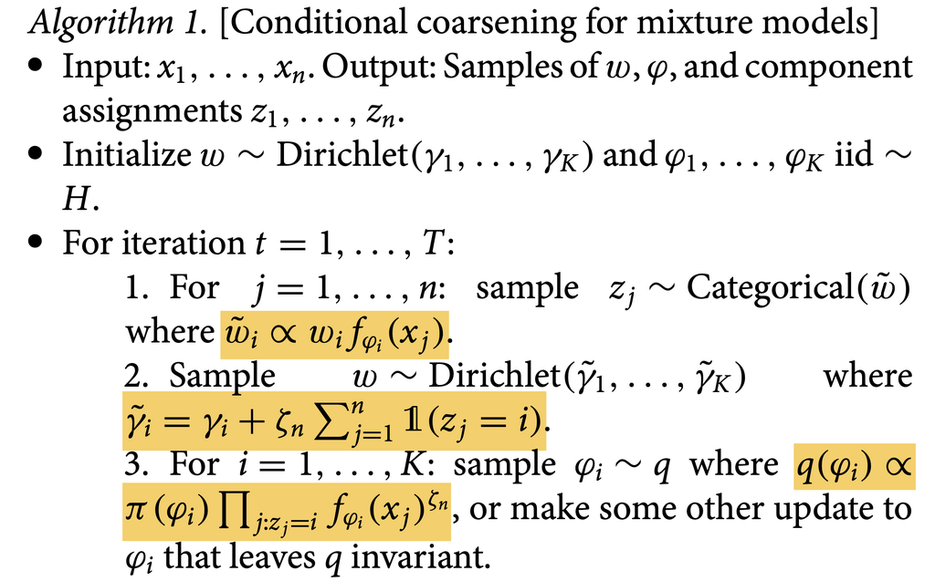

In the supplementary material S7.2.1. they say that this approach was chosen because it turns out to be equivalent to approximating the posterior with $q(\omega, \phi) \propto \pi(\omega, \phi) \prod_{i = 1}^{N} \left(w_{z_i} f_{\phi_{z_i}}(x_i) \right)^{\zeta(\alpha, n)}$.

To help “*escaping from local optima in which one cluster needs to be split into two or more clusters*” they also suggest to add a step between steps 1 and 2 in the algorithm above, during the first $T_{\text{init}}$ MCMC iterations. In this step, every $S$ iterations, if there are $k_n$ empty clusters, the largest $k_n$ clusters are randomly split into two clusters.

### Important properties

Interesting points to clarify and properties of the power likelihood/posterior approach are:

- The power likelihood does *not* imply a distribution on $x_{1:N}$ given $\theta$, so it does not involve a $\theta$-dependent normalization constant. Thus, the power posterior is *not* equivalent to the traditional posterior under a model with tempered density $\hat{f}(x \mid \theta, \zeta) \propto p_{\theta}(x)^{\zeta_{n}}$. It follows that the power likelihood approach is **not equivalent to renormalized tempering** or overdispersion.
- A useful interpretation is that the power posterior is only as concentrated as if the sample was of size $\zeta n < n$ (**sample-size adjustement**). ALso, the power-likelihood does *not* concentrate for $n \rightarrow \infty$ as this is *not wanted* if we assume that, no-matter the sample size, there exist a discrepancy between observed and idealized data distributions.
- A **disandvantage** of this approach is that if $\alpha$ is small then too much coarsening might be applied and the power posterior might underestimate model complexity and produce too large credible sets.

### Their results on mixtures

They empirically confirm two theoretically-expected benefits of using a power likelihood:

- More accurate estimation of the number of clusters in the presence of (even slight) discrepancy between observed and idealized data likelihoods. In particular, the power likelihood seems to help avoiding the creation of spurious, very small clusters that are commonly found due to likelihood mispecification.
- On flow cytometry data with ground truth manual cluster annotations, power likelihood leads to clusters which are much closer to the ground truth ones than with a traditional mixture of gaussians likelihood.

### Method for choosing $\alpha$

They propose a data-driven method for choosing $\alpha$, the parameter that determines the power $\zeta(n, \alpha)$ of the power likelihood.

This method consists of trying several values of $\alpha$ and computing a measure of fit and a measure of model complexity for the power posterior estimated with that $\alpha$ (e.g., in a MCMC sampler, obtain the average measures of fit and model complexity across iterations) and then choose the value of $\alpha$ corresponding to relatively high model fit for relatively low complexity.

This method can be computationally expensive and requires problem-specific choice of good measures of model fit and complexity.

Another data-driven way of choosing $\alpha$ is again trying a range of values on some train data and choose the one that performs best on some test data according to some performance measure.